# Final Proj 2

## Scientific Question: Do the genes and proteins that are used for the UV-repair pathway in humans (specifically in nucleotide excision repair) have a high correlation in terms of nucleotide sequence similarity and protein structures with each other?

Background Information: There are two main categories of nucleotide excision repair: global genome nucleotide excision repair (GG-NER), and transcription-coupled nucleotide excision repair (TC-NER)(Araujo and Kuraoka, 2019). These categories do not correlate that much with each other as the proteins do not have more similar functions when compared to other ones in the same category. I want to know if the genes and structure of proteins with similar functions will have an increased similarity.

I found the genes and proteins responsible for NER on a separate website (https://www.mdanderson.org/documents/Labs/Wood-Laboratory/human-dna-repair-genes.html). I used NCBI and PDB to find the genes of interest and downloaded the gene files (.fasta format) necessary through NCBI (https://www.ncbi.nlm.nih.gov/) and protein files(.pdb format) PDB (https://www.rcsb.org/). I used the genes ERCC2,ERCC3,XPC,XPA, GTF2H1, GTF2H2, XAB2, and LIG1 as my genes/proteins of interest. XPC and XPA both bind DNA. ERCC2 and ERCC3 both are helicases that move in the opposite direction. LIG1 is responsible for DNA ligase. GTF2H1 and GTF2H2 both make up the human core TFIIH. XAB2 is a pre-MRNA splicing factor. I used a pairwise sequence analysis to compare the nucleotide sequence between the different genes and a heatmap to plot them. I also used PyMol to visualize the genes from the PDB database. I also created a distancefinder function that shows the distance between two of the furthest atoms on a protein, which would ultimately be used to help compare the proteins structurally.

```
Araújo SJ, Kuraoka I. Nucleotide excision repair genes shaping embryonic development. Open Biol. 2019 Oct 31;9(10):190166. doi: 10.1098/rsob.190166. Epub 2019 Oct 30. PMID: 31662099; PMCID: PMC6833223.
```

https://pubmed.ncbi.nlm.nih.gov/31662099/

## Hypothesis: If the proteins, and thus genes, responsible for nucleotide excision repair have some similar functions to each other, then the proteins and the genes responsible for them in nucleotide excision repair will have the highest sequence and structural (specifically in terms of size) homology in relation to the ones that share the same functions.

If my hypothesis should be correct, then we should XPC be the most similar with XPA; ERCC2 should be the most similar to ERCC3; GTF2H1 should be the most similar to GTF2H2; and LIG1 and XAB2 could be similar to any or all of them but should not be almost identical to any because of their different functions.

# Part 1: Load Packages

Matplotlib: This is used to plot the heatmap and bar graph. It is a package that allows plots of various sizes and functions. It can be used to plot scatter plots and many other graphs for example. They have different functions that allow for easier creations of plots. It is especially useful for visualizing data because it can create graphs that are interactable and ones that are easy to draw patterns from. https://matplotlib.org/

Numpy: Numpy is used for mathematical equations. It can create large arrays and other useful information holders. Numpy is used in many python creations because it is so simple, fast, and efficient. We learned this in Datacamp and have used it before many times as well. I used it in this case to create an array to store the pairwise sequence alignment data. https://numpy.org/

Bio: This is an open source package that is mainly used for bio-related methods. I used this and its submodules and subpackages for the pairwise sequence alignment and the protein analysis. There are many useful functions overall as well as different submodules and subpackages that can be further imported. I used two these in my code (Bio.seq and Bio.PDB). We have also used this several times before in class. https://biopython.org/wiki/Download

Bio.Seq: This was also used in the pairwise sequence alignment method. This is used to make the bio sequences like nucleotides or amino acids into readable code as a string. This helps with understanding and digesting the sequences of different genes or proteins of interest. I used it for analyzing the different nucleotide sequences as I did not need to read in the amino acid sequences. Bio.seq also comes with other various functions that can be useful like my_seq.count(). https://biopython.org/docs/1.75/api/Bio.Seq.html

Bio.PDB: This is a package that is used for dealing with crystal structures. I used this in order to visualize and analyze the different proteins of interest. Bio.PDB.PDBParser is a module that is part of Bio.PDB. I used that specifically to analyze the structures. It allows the proteins to be stored as various forms of data. Atoms, residues, chains, models, and structures are all part of the data created when importing a protein. https://biopython.org/docs/1.75/api/Bio.PDB.html

```python
from Bio import SeqIO
import numpy as np
import matplotlib.pyplot as plt
from Bio import pairwise2
from Bio.Seq import Seq
from Bio.PDB import *
from Bio.PDB.PDBParser import PDBParser


#nothing special needs to be downloaded to load in the packages
```

# Part 2: Pairwise Sequence Alignment

Pairwise sequence alignment compares the individual nucleotides in the different genes with each other. Once done, you end up with a pairwise alignment score that shows how many nucleotides matched with each other. In the code I read in the nucleotide sequence of the genes in a fasta file in order to be compared for pairwise sequence alignment. The function uses a method called pairwise2.align.globalxx that is used to create a number and have the number assigned as an integer to a new numpy array. The array will then be converted to a heatmap in order to visualize the data.

```python
#Reads in the fasta file using SeqIO, Fasta is a global variable that contains the nucleotides of the different nucleotides
#SeqIO is used to convert the nucleotide sequence in the fasta file into readable and processable data as a list
#the fasta file was created using NCBI
Fasta = list(SeqIO.parse("DataFiles.fasta", "fasta"))
#Sets global variable size to the length of Fasta to be used in a for loop that runs through the entire list
size = len(Fasta)
#code check below
#print(size)

#creates empty array of (size,size) as the global variable 'alignments_score'
alignments_score = np.empty(shape=(size,size))

#function that is a nested for loop to do pairwise sequence alignment with arguments 'my_numpy_array' and 'size'
def pairwise_seq_heatmap(my_numpy_array, size):
#for loop
    for i in range(size):
#for loop
        for j in range(size):
        # x,y are local variables that only reads the nucleotide sequence from the list
            X = Fasta[i].seq
            Y = Fasta[j].seq
            # Code Check below
            #print(Fasta[i].id)

            #my_numpy_array is a newly created array that contains the global alignment scores and is a local variable
            #the package NumPy is useful for creating new forms of data storage like arrays and also contains many array functions
            my_numpy_array[i,j] = int(pairwise2.align.globalxx(X, Y, score_only=True))
    #returns array
    return my_numpy_array
#calls the function 'pairwise_seq_heatmap' and sets 'My_alignment_scores' as the output as a global variable
My_alignment_Scores = pairwise_seq_heatmap(alignments_score, size)
#code check
print(My_alignment_Scores)
```

```
[[20930. 13497. 13434. 13043. 13385. 13530. 13618.  8390.]
 [13497. 20930. 13472. 13151. 13286. 13302. 13493.  8489.]
 [13434. 13472. 20930. 13461. 13483. 13476. 13581.  8653.]
 [13043. 13151. 13461. 20811. 13437. 13242. 13232.  8768.]
 [13385. 13286. 13483. 13437. 21000. 13583. 13374.  8637.]
 [13530. 13302. 13476. 13242. 13583. 20930. 13558.  8533.]
 [13618. 13493. 13581. 13232. 13374. 13558. 20930.  8434.]
 [ 8390.  8489.  8653.  8768.  8637.  8533.  8434. 10021.]]
```

# Part 3: Heat map

A heat map is used to compare the similarities of the proteins/RNA through color visualization. A color bar will be added to show the degree of correlations of the proteins. This plot was used to visually analyze the alignment scores with each other. A higher or brighter color will mean that the two genes had more nucleotide homology. Further explanation in the analysis of results.

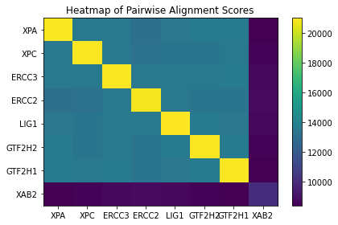

```python
#Sets a figure and ax variable equal to plt.subplots()
fig, ax = plt.subplots()

#Instructs the heat map to show the axes
im = ax.imshow(My_alignment_Scores, interpolation='nearest', aspect='auto')

# Add a colorbar to the right of the heatmap
cbar = ax.figure.colorbar(im)

#creates list of gene names to be set as the axes
axis = ['XPA','XPC','ERCC3','ERCC2','LIG1','GTF2H2','GTF2H1','XAB2']
ax.bar(axis,axis, width = 0)

#manually sets title
ax.set_title('Heatmap of Pairwise Alignment Scores')

#Set the X-axis & Y-Axis ticks
ax.set_xticks(np.arange(size))
ax.set_yticks(np.arange(size))

#Shows the heatmap
fig.tight_layout()
plt.show()
```

# Part 4: Homology Modeling

Using PyMOL, I will visualize the different proteins next to each other. I inserted pdb files from RCSB PDB into PyMOL to get the structures of the proteins. PyMOL is a program that helps visualize and compare different protein structures through its 3D visualization. I also created a function to determine the max distance two atoms have from each other to determine their relative size.

### PyMOL Imagining

I used PyMOL to look at the proteins both individually and comparatively. The image below is a .png file that was created from the PyMOL application. Using the application, I also moved and rotated the different proteins in order to better compare them.

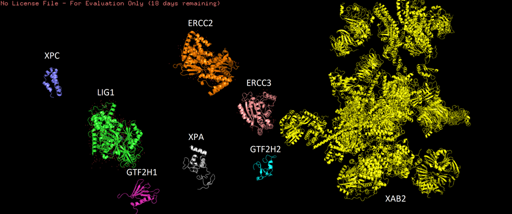

When comparing the proteins with each other, that the proteins' tertiary structures vary in size, shape, and complexity. There seems to be three distinct groups in relation to size. The first one, containing smaller ones are the purple (XPC), hot pink (GTF2H1), gray (XPA), peach (ERCC3), and light blue (GTF2H2). The second group, containing the medium ones are the green (LIG1), and orange (ERCC2). The last group, with an extreme outlier in size, is the yellow protein (XAB2). I mainly used the PyMOL software to get a basic understanding of what each protein looked like. This is overall used to become more familiar with the proteins and their structures.

# Part 5 Finding the maximum "height" of the protein

Because looking at a static 2D image with 3D proteins cannot prove or quantify protein similarity, I wrote a function that helps with identifying the max distance of any two atoms with each other in each protein. This helps to better visualize the differences in size of the proteins. These distances will then be compared to each other in order to determine structural similarity. I could not get two of the protein data to load/be read. The two that could not load were the medium sized proteins (LIG1 and ERCC2). I read in the data by downloading the pdb files from https://www.rcsb.org/. I used Bio.PDB as the main package in order to read the protein data and have each atom/residue/protein contain its own data. Specifically I looked at every labeled atom's coordinates and found the distances from each other. The max distance is the farthest apart any two atoms are in the protein and is thus the maximum "height" of the protein.

```python
#sets PDBParser function as p to simplify
p = PDBParser()
#creates global variables of the different proteins
#these are read in by downloading the pdb file from RCSB PDB and uploading them to jupyter
structureXPA = p.get_structure("XPA", "XPA.pdb")
structureXPC = p.get_structure("XPC", "XPC.pdb")
structureERCC3 = p.get_structure("ERCC3", "ERCC3.pdb")
structureGTF2H1 = p.get_structure("GTF2H1", "GTF2H1.pdb")
structureGTF2H2 = p.get_structure("GTF2H2", "GTF2H2.pdb")
structureXAB2 = p.get_structure("XAB2", "XAB2.pdb")
#These lines are commented out because their lines are discontinuous which makes them unable to be loaded in
#structureERCC2 = p.get_structure("ERCC2", "ERCC2.pdb")
#structureLIG1 = p.get_structure("LIG1", "LIG1.pdb")

#creates function distancefinder to find max distance with argument 'protein'
def distancefinder(protein):
    #creates local variables i to reset future while loop
    i=0
    #creates local variable maxdistance to find the max distance
    #it is set as 0 initially before any two points are compared
    maxdistance=0
    #makes residue_list which is a list of all the Object residues in the argument as a local variable
    residue_list=Selection.unfold_entities(protein, "R")
    #creates local variable newlist as an empty list to add the residue id number, because residue_list returns an object Residue
    #I need to find the id number as a str or int to be able to use it to find distances, in this case I converted it to int
    #I will use newlist later as the index of the protein structure to identify each atom and thus the atom's coordinates
    newlist=[]
    #creates local variable idnumber to add to newlist as the id number
    idnumber=0
    #while loop that goes through the entire residue_list
    while i < (len(residue_list)):
        #loops until the code matches the residue seqID with the local variable idnumber
        #idnumber increases until it matches the seqID; once it matches, it is added into newlist and resets to 0 to start over
        if(repr(residue_list[i]).find("resseq="+str(idnumber)+" ")== -1):
            idnumber+=1
        else:
            newlist.append(j)
            idnumber=0
            i+=1
    #code check; newlist is now completed with all of the residue's seqIDs in order to be able to find the atoms' coordinates
    #print(newlist)

    #two for loops to find the distance between all possible pairs of atoms
    for m in range(len(newlist)):
         for n in range(len(newlist)):
            try:
                #asks if the distance between the two atoms is greater than the max distance
                #protein[0]["A"][newlist[m]]["CA"] calls for the atom's coordinates at the residue with that seqID
                if (protein[0]["A"][newlist[m]]["CA"]-protein[0]["A"][newlist[n]]["CA"])>maxdistance:
                    #sets maxdistance to the new distance
                    maxdistance=protein[0]["A"][newlist[m]]["CA"]-protein[0]["A"][newlist[n]]["CA"]
                    #code check; max distance can only increase since it is only changed when the new distance is greater than it
                    #print(maxdistance)
            except:
                pass
    #returns maxdistance
    return maxdistance

#prints max distances of the different Proteins
#code checks
print("The max distance for XPA is",distancefinder(structureXPA))
print("The max distance for XPC is",distancefinder(structureXPC))
print("The max distance for ERCC3 is",distancefinder(structureERCC3))
print("The max distance for GTF2H1 is",distancefinder(structureGTF2H1))
print("The max distance for GTF2H2 is",distancefinder(structureGTF2H2))
print("The max distance for XAB2 is",distancefinder(structureXAB2))
```

[output not shown]

# Plotting results

Matplotlib is used again to create a bar graph that shows the maximum distance two atoms have on the proteins. A bar graph is useful in comparing static numbers with different categories. It helps the viewer visualize the differences or changes in the numbers given. Here I take the different max distances for each protein and plot them to the bar graph.

[figure not shown]

```python
#Sets a figure variable as the plot figure
fig = plt.figure()

#adds axes to the figure
ax=fig.add_axes([0,0,1,1])

#creates global variables xaxis and yaxis to be set to the figure axes; xaxis is the genes and yaxis is its corresponding size
xaxis = ['XPA','XPC','ERCC3','GTF2H2','GTF2H1','XAB2']
yaxis = [distancefinder(structureXPA),distancefinder(structureXPC),distancefinder(structureERCC3),distancefinder(structureGTF2H1),distancefinder(structureGTF2H2),distancefinder(structureXAB2)]

#sets the axis as the desired lists
ax.bar(xaxis,yaxis)

#manually creates title
ax.set_title('Height of Protein')

#manually sets the x and yaxis labels
ax.set_ylabel('Max Height')
ax.set_xlabel('Protein')
#shows the plot
plt.show()
```

# Analyzing results

The heatmap successfully shows the pairwise sequence alignment comparisons between the different nucleotide sequences. I had the pairwise sequence alignment do around the first 20,000 nucleotides of all genes because it would be an easier comparison as a more diverse number would be a little harder to follow visually because the color variance; however, XAB2 only had around 10,000 nucleotides, so I could not change it to 20,000. The heatmap shows no definite correlation between any two or more different genes and their nucleotide sequences. The diagonals are the brightest and constant because those are the ones in which it compares the sequences to itself, showing the total amount of nucleotides that were used for comparison. All the rest of the heap is almost the exact same color throughout the heatmap except for XAB2; this is because of its smaller sample size of comparison. Taking XAB2's smaller number of nucleotides into account, this suggests that my hypothesis is incorrect in that there are no two or more genes that have a higher correlation or sequence homology with each other because each row and column have a constant color.